# AMPBA 2022W Batch 17

## Probability and Statistics using R - Assignment

### Name : Bhargavi Peddapati, PG ID : 12120067

### *Answer for Question 1)

Given µ= 77.0 and σ = 3.4 and formula for z-score

$$Z = (x - µ )/σ$$

### Applying z-score formula for the questions below

### *Answer for Question 1 (a)

```
      Z = (72.6-77.0)/3.4
      Z = -1.294118
      p(x<72.6) = p(Z<-1.29)
                = 1- F(1.29)
                = 1- 0.9015 , F(1.29) value taken from standard normal table from slides given
                = 0.0985
      p(x<72.6) = p(Z<-1.29) = 0.0985
      In percentage,
      p(x<72.6) = p(Z<-1.29) = 0.0985*100 = 9.85% is the probability of random variable less than 72.6
```

#### R Code Result

##### Approach I

```r
          prob.of.random.var.less.than.72.6 <- (72.6-77.0)/3.4
          print(paste(" ((72.6-77.0)/3.4)  =", prob.of.random.var.less.than.72.6))
```

```
## [1] " ((72.6-77.0)/3.4)  = -1.29411764705883"
```

```r
          print(paste(" Using pnorm function : p(x<72.6)  = ",pnorm(72.6,mean=77.0,sd=3.4)))
```

```
## [1] " Using pnorm function : p(x<72.6)  =  0.097812393434633"
```

##### Approach II

```r
          randonVariablefun <- function(x,y,z)
         {
             z <- (x-y)/z
             prob <- pnorm(z)
             return(prob)
         }
         randonVariablefun(72.6,77.0,3.4)
```

```
## [1] 0.09781239
```

### *Answer for Question 1 (b)

```
      Z = (88.5 -77.0)/3.4
      Z = 3.382353
      p(x>88.5) = p(Z>3.38)
                = 1- F(3.38)
                = 1- 0.9996 , F(3.38) value taken from standard normal table
                = 0.0004
      p(x>88.5) = p(Z>3.38) = 0.0004
      In percentage,
      p(x>88.5) = p(Z>3.38) = 0.0004*100 = 0.04% is the probability of random variable greater than 88.5
```

#### R Code Result

##### Approach I

```r
          prob.of.random.var.greater.than.88.5 <- (88.5 -77.0)/3.4
          print(paste(" ((88.5 -77.0)/3.4)  =",prob.of.random.var.greater.than.88.5))
```

```
## [1] " ((88.5 -77.0)/3.4)  = 3.38235294117647"
```

```r
          greater.88.5 <- (1-pnorm(88.5,mean=77.0,sd=3.4))
          print(paste(" Using pnorm function : p(x>88.5)  = ",greater.88.5))
```

```
## [1] " Using pnorm function : p(x>88.5)  =  0.000359338725646752"
```

##### Approach II

```r
         randonVariablefun <- function(x,y,z)
         {
            z <- (x-y)/z
            prob <- pnorm(z)
            return(prob)
         }
         (1-randonVariablefun(88.5,77.0,3.4))
```

```
## [1] 0.0003593387
```

### *Answer for Question 1 (c)

```
      Z1 = (81-77.0)/3.4
      Z1 = 1.176471
      p(x>81)   = p(Z1>1.17)
                = F(1.17)
                = 0.8790 , F(1.17) value taken from standard normal table
      p(x>81) = p(Z1>1.17) = 0.8790
      Z2 = (84-77.0)/3.4
      Z2 = 2.058824
      p(x<84) = p(Z2<2.05)
              = F(2.05)
              = 0.9798
      p(81<x<84)=p(81<Z<84)
                =F(2.05)-F(1.17)
                =0.9798-0.8790
                =0.1008
      In percentage,
      p(81<x<84)=p(81<Z<84) = 0.1008*100 = 10.08% is the probability of random variable between 81 and 84
```

#### R Code Result

##### Approach I

```r
          prob.of.random.var.between.81.and.84 <- ((84-77.0)/3.4) - ((81-77.0)/3.4)
          print(paste(" ((84-77.0)/3.4) - ((81-77.0)/3.4)  =",prob.of.random.var.between.81.and.84))
```

```
## [1] " ((84-77.0)/3.4) - ((81-77.0)/3.4)  = 0.882352941176471"
```

```r
          print(paste(" Using pnorm function : p(81<x<84) =" ,(pnorm(84,mean=77.0,sd=3.4)-pnorm(81,mean=77.0,sd=3.4))))
```

```
## [1] " Using pnorm function : p(81<x<84) = 0.0999478660096137"
```

##### Approach II

```r
    randonVariablefun <- function(x1,x2,y,z)
     {
       z1 <- ((x1-y)/z)
       z2 <- ((x2-y)/z)
       prob <- pnorm(z2)-pnorm(z1)
       return(prob)
     }
    randonVariablefun(81,84,77.0,3.4)
```

```
## [1] 0.09994787
```

### *Answer for Question 1 (d)

```
      Z1 = (56-77.0)/3.4
      Z1 = -6.176471
      p(x>56)   = p(Z1>-6.17)
                = F(-6.17)
      Z2 = (92-77.0)/3.4
      Z2 = 4.411765
      p(x<92) = p(Z2<4.41)
              = F(4.41)
      p(56<x<92)=p(56<Z<92)
                =F(4.41)-F(-6.17)
      Values not found from standard normal table assuming 1 or near to it.
      p(56<x<92)=p(56<Z<92) = 1 or 0.99999 is the probability of random variable between 56 and 92
```

#### R Code Result

##### Approach I

```r
          prob.of.random.var.between.56.and.92 <- ((92-77.0)/3.4) - ((56-77.0)/3.4)
          print(paste(" ((92-77.0)/3.4) - ((56-77.0)/3.4)  =",prob.of.random.var.between.56.and.92))
```

```
## [1] " ((92-77.0)/3.4) - ((56-77.0)/3.4)  = 10.5882352941176"
```

```r
          print(paste(" Using pnorm function : p(56<x<92) =" ,(pnorm(92,mean=77.0,sd=3.4)-pnorm(56,mean=77.0,sd=3.4))))
```

```
## [1] " Using pnorm function : p(56<x<92) = 0.999994873097099"
```

##### Approach II

```r
    randonVariablefun <- function(x1,x2,y,z)
     {
       z1 <- ((x1-y)/z)
       z2 <- ((x2-y)/z)
       prob <- pnorm(z2)-pnorm(z1)
       return(prob)
     }
    randonVariablefun(56,92,77.0,3.4)
```

```
## [1] 0.9999949
```

### *Answer for Question 2)

Given µ= 145 and σ = 12 and formula for z-score

$$Z = (x - µ )/σ$$

### *Answer for Question 2 (a)

```
      Z1 = (130-145)/12
      Z1 = -1.25
      p(x>130) = p(Z1>-1.25)
               = F(-1.25)
               = 1- F(1.25)
               = 1- 0.8944 , F(1.25) value taken from standard normal table
               = 0.1056
      Z2 = (160-145)/12
      Z2 = 1.25
      p(x<160) = p(Z2<1.25)
               = F(1.25)
               = 0.8944 , F(1.25) value taken from standard normal table
      p(130<x<160) = p(130<Z<160)
                   = F(1.25) - F(-1.25)
                   = 0.8944 - 0.1056
                   = 0.7888
      In percentage,
      p(130<x<160) = p(130<Z<160) = 0.7888*100 = 78.88% is the probability of random variable between 130 and 160 minutes
```

#### R Code Result

##### Approach I

```r
          prob.of.random.var.between.130.and.160 <- ((160-145)/12 - (130-145)/12)
          print(paste(" ((160-145)/12 - (130-145)/12)  =",prob.of.random.var.between.130.and.160))
```

```
## [1] " ((160-145)/12 - (130-145)/12)  = 2.5"
```

```r
          print(paste(" Using pnorm function : p(130<x<160) =" ,(pnorm(160,mean=145,sd=12)-pnorm(130,mean=145,sd=12))*100,"%"))
```

```
## [1] " Using pnorm function : p(130<x<160) = 78.8700452666289 %"
```

##### Approach II

```r
    randonVariablefun <- function(x1,x2,y,z)
     {
       z1 <- ((x1-y)/z)
       z2 <- ((x2-y)/z)
       prob <- pnorm(z2)-pnorm(z1)
       return(prob)
     }
    randonVariablefun(130,160,145,12)
```

```
## [1] 0.7887005
```

### *Answer for Question 2 (b)

```
      Z = (130-145)/12
      Z = -1.25
      p(x<130) = p(Z<-1.25)
               = F(-1.25)
               = 1 - F(1.25)
               = 1 - 0.8944 , F(1.25) value taken from standard normal table
               = 0.1056
      In percentage,
      p(x<130) = p(Z<-1.25) = 0.1056*100 = 10.56% is the probability of random variable less than 130 minutes.
```

#### R Code Result

##### Approach I

```r
          prob.of.random.var.less.than.130 <- ((130-145)/12)
          print(paste(" ((130-145)/12)  =",prob.of.random.var.less.than.130))
```

```
## [1] " ((130-145)/12)  = -1.25"
```

```r
          print(paste(" Using pnorm function : p(x<130) =" ,(pnorm(130,mean=145,sd=12))*100,"%"))
```

```
## [1] " Using pnorm function : p(x<130) = 10.5649773666855 %"
```

##### Approach II

```r
     randonVariablefun <- function(x,y,z)
       {
         z <- (x-y)/z
         prob <- pnorm(z)
         return(prob)
       }
     randonVariablefun(130,145,12)
```

```
## [1] 0.1056498
```

### *Answer for Question 3)

### *Answer for Question 3 (a)

```
      Two outcomes: True , False
      Probability of question correct : 1/2
      First 5 times : (1/2) * (1/2) * (1/2) * (1/2) * (1/2) = 1/32
```

#### R Code Result

```r
         first.five.correct <- (1/2) * (1/2) * (1/2) * (1/2) * (1/2)
         print(paste(" Probability of the student got first five quesions correct ",first.five.correct))
```

```
## [1] " Probability of the student got first five quesions correct  0.03125"
```

### *Answer for Question 3 (b)

According to the Binomial Distribution formula,

```
 p^x         = 0.5^5 = 0.03125
 (1-p)^n-x   = (1-0.5)^(15-5) = 0.00097
 n!/(n-x)!x! = (15!/((15-5)!5!)) = 3003
```

```r
         print(paste(" The student got five questions correct ",0.03125 * 0.0009765625 * 3003))
```

```
## [1] " The student got five questions correct  0.091644287109375"
```

### *Answer for Question 4)

```
  Mean = (35+42)/2 = 38.5
  Standard deviation = (42-35)/2 = 3.5
```

#### R Code Result

```r
          mean <- (35+42)/2
          print(paste(" mean ",mean))
```

```
## [1] " mean  38.5"
```

```r
          Standard.deviation <- (42-35)/2
          print(paste(" Standard.deviation ",Standard.deviation))
```

```
## [1] " Standard.deviation  3.5"
```

### *Answer for Question 5)

$$P(A \mid B) = P(A \cap B)/P(B)$$

$$P(E1) = 55$$

$$P(E2 \cap E1) = 30$$

$$P(E2 \mid E1) = 30/55 = 54.54$$

### *Answer for Question 6)

$$P(A \mid B) = P(A \cap B)/P(B)$$

$$P(TV) = 82$$

$$P(TV \cap DVD) = 62$$

$$P(DVD \mid TV) = 62/82 = 75.60976$$

### *Answer for Question 7)

All possibilities , HHH, HHT, HTT, TTT, THH, TTH, THT, HTH

$$2^{3} = 8$$

### * 1) All three heads

```
    HHH

    1/8
```

### * 2) Exactly one head

```
    HTT, TTH, THT

    3/8
```

### * 3)

```
    Exactly one head

    HTT, TTH, THT

    3/8

    Now outcomes 7

    Atleast two heads

    HHH, HHT, THH, HTH

    4/7
```

### *Answer for Question 8)

[output not shown]

```r
     randonVariablefun <- function(x,y,z)
       {
         z <- (x-y)/z
         prob <- pnorm(z)
         return(prob)
       }
     randonVariablefun(100,90,10)
```

```
## [1] 0.8413447
```

### *Answer for Question 9)

P(A) = Bag1 is from 1994 P(B) = Bag2 is from 1996

the probability that the yellow from both p(A) = p(B) = 1/2

Case 1)

Probability of getting yellow from p(A) = 1/20 = 0.2 Probability of getting green from p(B) = 1/20 = 0.2

Case 2)

Probability of getting green from p(A) = 1/10 = 0.1 Probability of getting yellow from p(B) = 1/140 = 0.14

```r
    0.5 * 0.2 * 0.2+ 0.5 * 0.1 * 0.14
```

```
## [1] 0.027
```

### *Answer for Question 10)

Three months period for the downloaded file is from 2021-10-25 to 2022-01-24

```r
    walmart <- read.csv("WMT.csv");
    head(walmart)
```

```
##         Date   Open   High    Low  Close Adj.Close  Volume
## 1 2021-10-25 148.78 150.52 148.01 150.06  149.4582 6429300
## 2 2021-10-26 150.00 150.55 148.46 148.75  148.1535 5806200
## 3 2021-10-27 148.96 149.02 147.39 147.53  146.9384 4855200
## 4 2021-10-28 148.34 148.98 147.71 148.45  147.8547 4199500
## 5 2021-10-29 147.91 150.10 147.56 149.42  148.8208 7328600
## 6 2021-11-01 149.98 150.75 149.35 149.79  149.1893 4183200
```

### *Answer for Question 10 (a)

```r
    mean.walmart <- mean(walmart$Close)
    print(paste(" Mean of stock prices  ",mean.walmart))
```

```
## [1] " Mean of stock prices   143.885713809524"
```

```r
    standard.deviation.walmart <- sd(walmart$Close)
    print(paste(" Standard Deviation of stock prices  ",standard.deviation.walmart))
```

```
## [1] " Standard Deviation of stock prices   3.9165097652918"
```

### *Answer for Question 10 (b)

```r
    shildq <- read.csv("SHLDQ.csv");
    head(shildq)
```

```
##         Date Open High  Low Close Adj.Close Volume
## 1 2021-10-25 0.03 0.03 0.01  0.02      0.02 152800
## 2 2021-10-26 0.03 0.03 0.01  0.01      0.01 652700
## 3 2021-10-27 0.01 0.02 0.01  0.02      0.02 298300
## 4 2021-10-28 0.02 0.02 0.01  0.01      0.01 345100
## 5 2021-10-29 0.01 0.02 0.01  0.01      0.01 233200
## 6 2021-11-01 0.01 0.02 0.01  0.01      0.01 258400
```

```r
    mean.shildq <- mean(shildq$Close)
    print(paste(" Mean of stock prices of shildq  ",mean.shildq))
```

```
## [1] " Mean of stock prices of shildq   0.016984126984127"
```

```r
    standard.deviation.shildq <- sd(shildq$Close)
    print(paste(" Standard Deviation of stock prices of shildq  ",standard.deviation.shildq))
```

```
## [1] " Standard Deviation of stock prices of shildq   0.00638418424700791"
```

### *Answer for Question 10 (c)

```r
    walmart.cv <- sd(walmart$Close) / mean(walmart$Close)
    print(paste(" The coefficient of variation (CV) of  Walmart ",walmart.cv))
```

```
## [1] " The coefficient of variation (CV) of  Walmart  0.0272195874183624"
```

```r
    shildq.cv <- sd(shildq$Close) / mean(shildq$Close)
    print(paste(" The coefficient of variation (CV) of  shildq ",shildq.cv))
```

```
## [1] " The coefficient of variation (CV) of  shildq  0.375891222020092"
```

### *Answer for Question 10 (d)

[output not shown]

### *Answer for Question 10 (e)

```r
    DJIA <- read.csv("DJIA.csv");
    head(DJIA)
```

```
##           Date      Open      High       Low   Close. Adj.Close       Volume
## 1 Jan 24, 2022 34,070.61 34,420.99 33,150.33 34364.50 34,364.50 66,40,10,000
## 2 Jan 21, 2022 34,701.69 34,896.67 34,229.55 34265.37 34,265.37 52,38,80,000
## 3 Jan 20, 2022 35,102.66 35,490.20 34,670.12 34715.39 34,715.39 36,90,70,000
## 4 Jan 19, 2022 35,412.30 35,547.83 35,015.49 35028.65 35,028.65 39,30,80,000
## 5 Jan 18, 2022 35,661.76 35,661.76 35,262.02 35368.47 35,368.47 42,72,60,000
## 6 Jan 14, 2022 35,996.43 35,996.43 35,641.49 35911.81 35,911.81 38,92,00,000
```

```r
    DJIA.cv <- sd(DJIA$Close) / mean(DJIA$Close)
    print(paste(" The coefficient of variation (CV) of  DJIA ",DJIA.cv))
```

```
## [1] " The coefficient of variation (CV) of  DJIA  0.01714404845412"
```

### *Answer for Question 10 (f)

```r
    walmart.hundred.shares <- walmart$Close*100
    walmart.hundred.shares.mean <- mean(walmart.hundred.shares)
    print(paste(" The mean of the daily market price for three months is ",walmart.hundred.shares.mean))
```

```
## [1] " The mean of the daily market price for three months is  14388.5713809524"
```

```r
    walmart.hundred.shares.sd <- sd(walmart.hundred.shares)
    print(paste(" The standard deviation of the daily market price for three months is ",walmart.hundred.shares.sd))
```

```
## [1] " The standard deviation of the daily market price for three months is  391.65097652918"
```

### *Answer for Question 11)

```r
    library(readxl)
    prob.assignment.dataset <- read_excel("Prob_Assignment_Dataset.xlsx", range=cell_cols("A:L"))
    head(prob.assignment.dataset)
```

```
## # A tibble: 6 x 12
##   day                 site  new_customer platform visits distinct_sessio~ orders
##   <dttm>              <chr>        <dbl> <chr>     <dbl>            <dbl>  <dbl>
## 1 2013-01-01 00:00:00 Acme             1 Android      24               16     14
## 2 2013-01-01 00:00:00 Acme             1 BlackBe~      0                0      0
## 3 2013-01-01 00:00:00 Sort~            1 iPad          0                0      0
## 4 2013-01-01 00:00:00 Acme             1 Windows     922              520    527
## 5 2013-01-01 00:00:00 Botly            1 Android      11               10     11
## 6 2013-01-01 00:00:00 Acme             1 Macinto~    384              214    213
## # ... with 5 more variables: gross_sales <dbl>, bounces <dbl>,
## #   add_to_cart <dbl>, product_page_views <dbl>, search_page_views <dbl>
```

```r
     table.of.site <- table(prob.assignment.dataset$site)
     table.of.site
```

```
##
##     Acme    Botly Pinnacle   Sortly  Tabular Widgetry
##     7392      804     5725     5532      804      804
```

#### *Analysis

Acme has highest used site.

```r
     table.of.platform <- table(prob.assignment.dataset$platform)
     table.of.platform
```

```
##
##      Android   BlackBerry     ChromeOS          iOS         iPad       iPhone
##         3172         1589         1349         3435          459          468
##        Linux    Macintosh       MacOSX        Other    SymbianOS      Unknown
##         2036          333         2054          327           74         1641
##      Windows WindowsPhone
##         2399         1315
```

#### *Analysis

```r
     table.of.new.customer <- table(prob.assignment.dataset$new_customer)
     table.of.new.customer
```

```
##
##    0    1
## 7066 5736
```

#### *Analysis

```r
    names(prob.assignment.dataset)
```

```
##  [1] "day"                "site"               "new_customer"
##  [4] "platform"           "visits"             "distinct_sessions"
##  [7] "orders"             "gross_sales"        "bounces"
## [10] "add_to_cart"        "product_page_views" "search_page_views"
```

```r
    str(prob.assignment.dataset)
```

```
## tibble [21,061 x 12] (S3: tbl_df/tbl/data.frame)
##  $ day               : POSIXct[1:21061], format: "2013-01-01" "2013-01-01" ...
##  $ site              : chr [1:21061] "Acme" "Acme" "Sortly" "Acme" ...
##  $ new_customer      : num [1:21061] 1 1 1 1 1 1 1 1 0 0 ...
##  $ platform          : chr [1:21061] "Android" "BlackBerry" "iPad" "Windows" ...
##  $ visits            : num [1:21061] 24 0 0 922 11 384 14 1 41 448 ...
##  $ distinct_sessions : num [1:21061] 16 0 0 520 10 214 10 0 27 368 ...
##  $ orders            : num [1:21061] 14 0 0 527 11 213 4 0 6 36 ...
##  $ gross_sales       : num [1:21061] 1287 13 98 60753 1090 ...
##  $ bounces           : num [1:21061] 4 0 0 149 0 65 4 0 6 80 ...
##  $ add_to_cart       : num [1:21061] 16 0 0 610 11 245 7 0 12 79 ...
##  $ product_page_views: num [1:21061] 104 1 0 3914 4 ...
##  $ search_page_views : num [1:21061] 192 0 0 7367 19 ...
```

#### * Analysis of visits

```r
    summary.of.visits <- summary(prob.assignment.dataset$visits)
    summary.of.visits
```

```
##    Min. 1st Qu.  Median    Mean 3rd Qu.    Max.
##       0       3      24    1935     360  136057
```

```r
    standard.deviation.visits <- sd(prob.assignment.dataset$visits)
    standard.deviation.visits
```

```
## [1] 7448.607
```

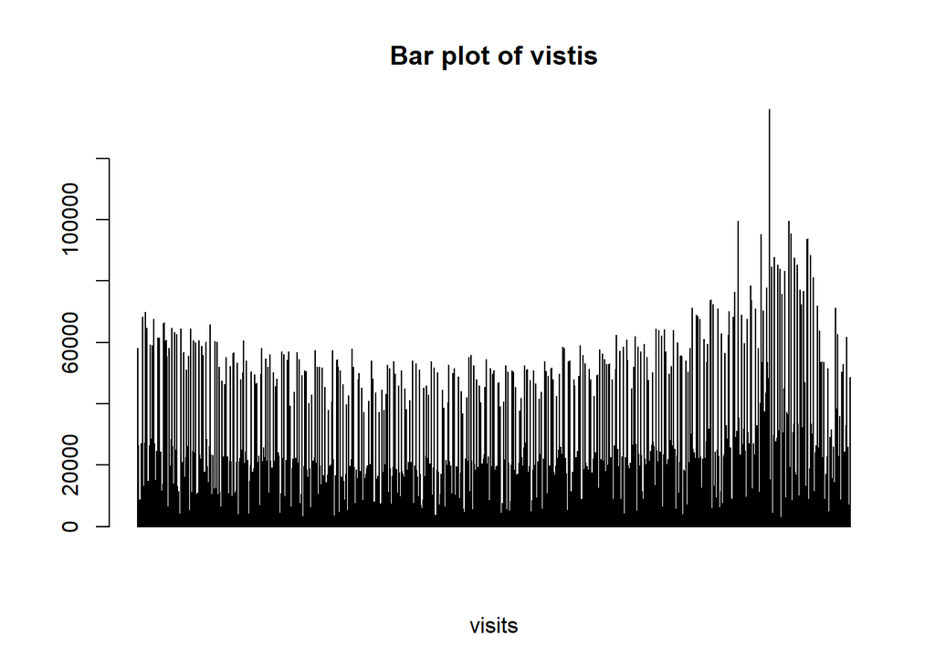

```r
    bar.plot.visits <- barplot(prob.assignment.dataset$visits,main = "Bar plot of vistis", xlab = "visits")
```

```r
    head(bar.plot.visits)
```

```
##      [,1]
## [1,]  0.7
## [2,]  1.9
## [3,]  3.1
## [4,]  4.3
## [5,]  5.5
## [6,]  6.7
```

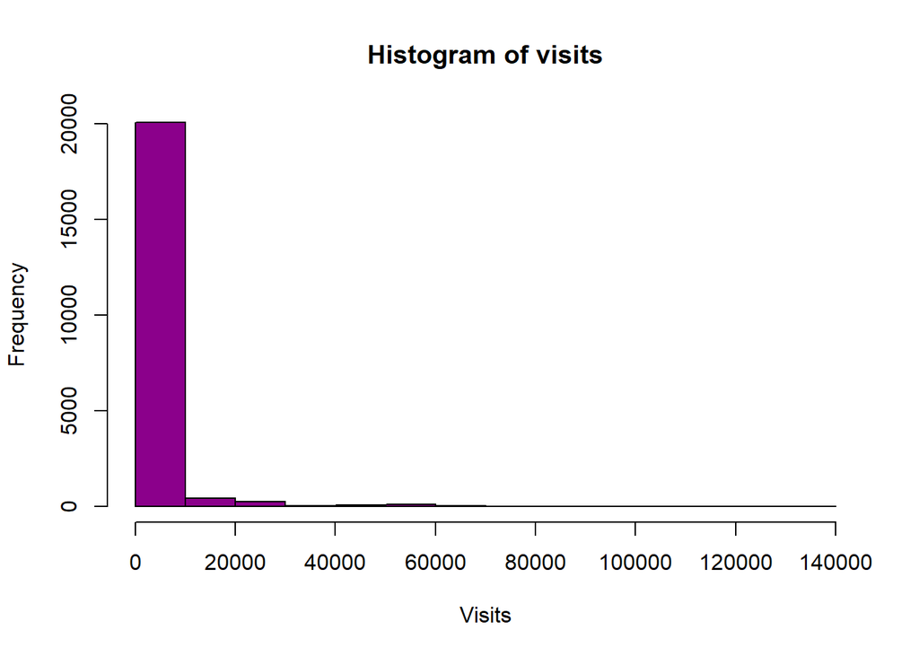

```r
    histogram.visits <- hist(prob.assignment.dataset$visits,main="Histogram of visits", xlab="Visits", col="darkmagenta")
```

```r
    head(histogram.visits)
```

```
## $breaks
##  [1]      0  10000  20000  30000  40000  50000  60000  70000  80000  90000
## [11] 100000 110000 120000 130000 140000
##
## $counts
##  [1] 20053   445   249    51    73   116    42    17     9     5     0     0
## [13]     0     1
##
## $density
##  [1] 9.521390e-05 2.112910e-06 1.182280e-06 2.421537e-07 3.466122e-07
##  [6] 5.507811e-07 1.994207e-07 8.071791e-08 4.273301e-08 2.374056e-08
## [11] 0.000000e+00 0.000000e+00 0.000000e+00 4.748113e-09
##
## $mids
##  [1]   5000  15000  25000  35000  45000  55000  65000  75000  85000  95000
## [11] 105000 115000 125000 135000
##
## $xname
## [1] "prob.assignment.dataset$visits"
##
## $equidist
## [1] TRUE
```

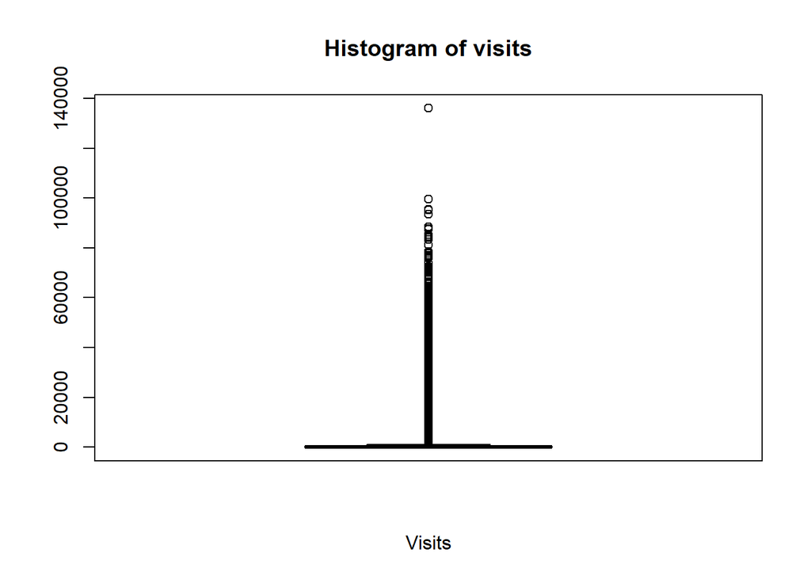

```r
     box.plot.visits <- boxplot(prob.assignment.dataset$visits,main="Histogram of visits", xlab="Visits")
```

```r
     head(box.plot.visits)
```

```
## $stats
##      [,1]
## [1,]    0
## [2,]    3
## [3,]   24
## [4,]  360
## [5,]  895
##
## $n
## [1] 21061
##
## $conf
##          [,1]
## [1,] 20.11326
## [2,] 27.88674
```

[output cut: 486 more lines]

#### * Analysis of distinct_sessions

```r
    summary.of.distinct_sessions <- summary(prob.assignment.dataset$distinct_sessions)
    summary.of.distinct_sessions
```

```
##    Min. 1st Qu.  Median    Mean 3rd Qu.    Max.
##       0       2      19    1515     274  107104
```

```r
    standard.deviation.distinct_sessions <- sd(prob.assignment.dataset$distinct_sessions)
    standard.deviation.distinct_sessions
```

```
## [1] 5925.833
```

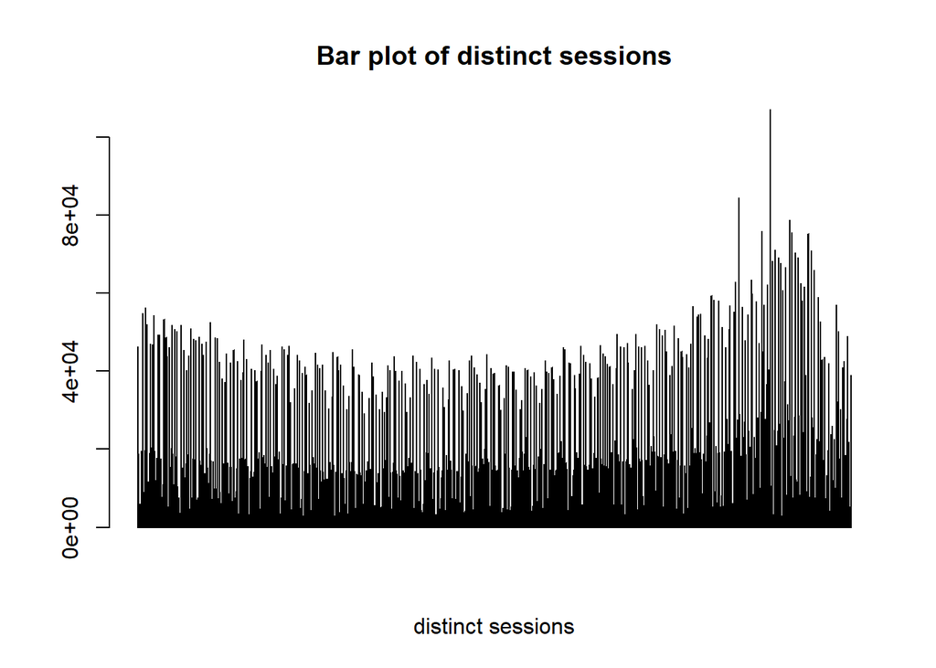

```r
    bar.plot.distinct_sessions <- barplot(prob.assignment.dataset$distinct_sessions,main = "Bar plot of distinct sessions", xlab = "distinct sessions")
```

```r
    head(bar.plot.distinct_sessions)
```

```
##      [,1]
## [1,]  0.7
## [2,]  1.9
## [3,]  3.1
## [4,]  4.3
## [5,]  5.5
## [6,]  6.7
```

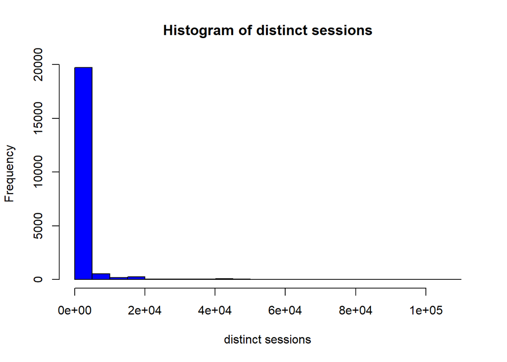

```r
    histogram.distinct_sessions <- hist(prob.assignment.dataset$distinct_sessions,main="Histogram of distinct sessions", xlab="distinct sessions", col="blue")
```

```r
    head(histogram.distinct_sessions)
```

```
## $breaks
##  [1]      0   5000  10000  15000  20000  25000  30000  35000  40000  45000
## [11]  50000  55000  60000  65000  70000  75000  80000  85000  90000  95000
## [21] 100000 105000 110000
##
## $counts
##  [1] 19716   529   192   260    55    30    35    58    81    47    23    14
## [13]     6     6     3     4     1     0     0     0     0     1
##
## $density
##  [1] 1.872276e-04 5.023503e-06 1.823275e-06 2.469019e-06 5.222924e-07
##  [6] 2.848868e-07 3.323679e-07 5.507811e-07 7.691942e-07 4.463226e-07
## [11] 2.184132e-07 1.329472e-07 5.697735e-08 5.697735e-08 2.848868e-08
## [16] 3.798490e-08 9.496225e-09 0.000000e+00 0.000000e+00 0.000000e+00
## [21] 0.000000e+00 9.496225e-09
##
## $mids
##  [1]   2500   7500  12500  17500  22500  27500  32500  37500  42500  47500
## [11]  52500  57500  62500  67500  72500  77500  82500  87500  92500  97500
## [21] 102500 107500
##
## $xname
## [1] "prob.assignment.dataset$distinct_sessions"
##
## $equidist
## [1] TRUE
```

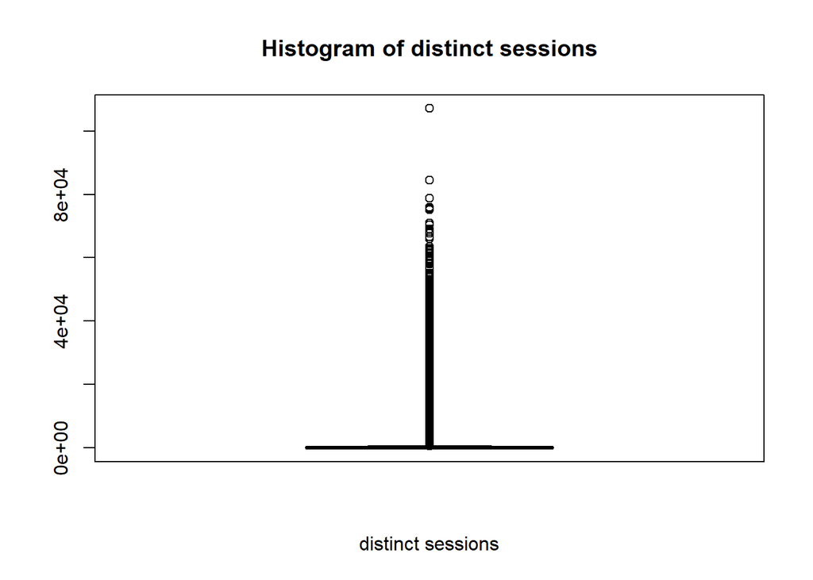

```r
     box.plot.distinct_sessions <- boxplot(prob.assignment.dataset$distinct_sessions,main="Histogram of distinct sessions", xlab="distinct sessions")
```

```r
     head(box.plot.distinct_sessions)
```

```
## $stats
##      [,1]
## [1,]    0
## [2,]    2
## [3,]   19
## [4,]  274
## [5,]  681
##
## $n
## [1] 21061
##
## $conf
##          [,1]
## [1,] 16.03867
## [2,] 21.96133
```

[output cut: 468 more lines]

#### * Analysis of orders

```r
    summary.of.orders <- summary(prob.assignment.dataset$orders)
    summary.of.orders
```

```
##    Min. 1st Qu.  Median    Mean 3rd Qu.    Max.
##    0.00    0.00    0.00   62.38    7.00 4916.00
```

```r
    standard.deviation.orders <- sd(prob.assignment.dataset$orders)
    standard.deviation.orders
```

```
## [1] 260.2793
```

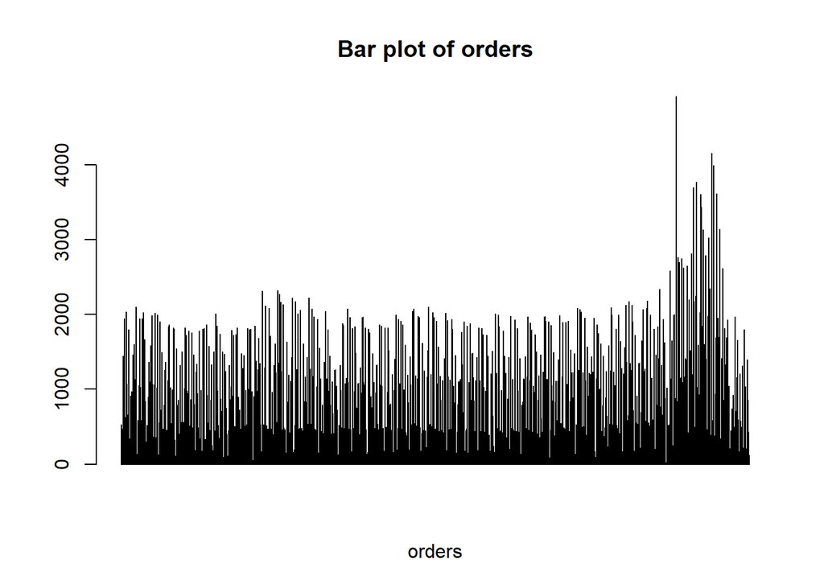

```r
    bar.plot.orders <- barplot(prob.assignment.dataset$orders,main = "Bar plot of orders", xlab = "orders")
```

```r
    head(bar.plot.orders)
```

```
##      [,1]
## [1,]  0.7
## [2,]  1.9
## [3,]  3.1
## [4,]  4.3
## [5,]  5.5
## [6,]  6.7
```

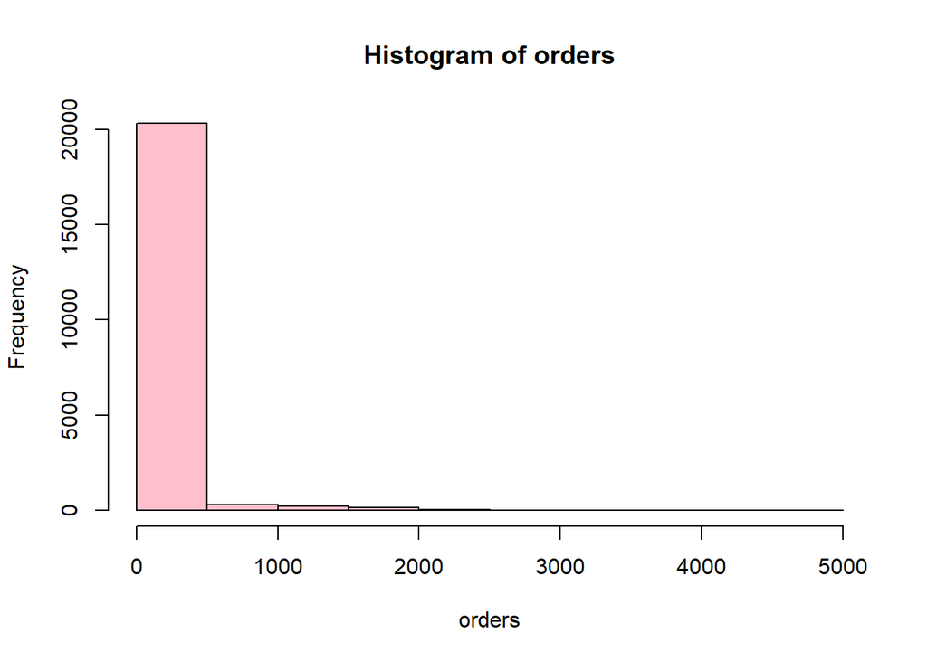

```r
    histogram.orders <- hist(prob.assignment.dataset$orders,main="Histogram of orders", xlab="orders", col="pink")
```

```r
    head(histogram.orders)
```

```
## $breaks
##  [1]    0  500 1000 1500 2000 2500 3000 3500 4000 4500 5000
##
## $counts
##  [1] 20303   310   231   150    47     9     4     5     1     1
##
## $density
##  [1] 1.928019e-03 2.943830e-05 2.193628e-05 1.424434e-05 4.463226e-06
##  [6] 8.546603e-07 3.798490e-07 4.748113e-07 9.496225e-08 9.496225e-08
##
## $mids
##  [1]  250  750 1250 1750 2250 2750 3250 3750 4250 4750
##
## $xname
## [1] "prob.assignment.dataset$orders"
##
## $equidist
## [1] TRUE
```

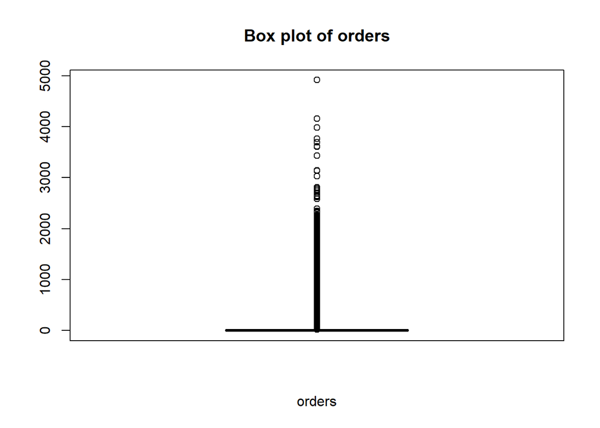

```r
     box.plot.orders <- boxplot(prob.assignment.dataset$orders,main="Box plot of orders", xlab="orders")
```

```r
     head(box.plot.orders)
```

```
## $stats
##      [,1]
## [1,]    0
## [2,]    0
## [3,]    0
## [4,]    7
## [5,]   17
##
## $n
## [1] 21061
##
## $conf
##             [,1]
## [1,] -0.07621064
## [2,]  0.07621064
```

[output cut: 338 more lines]

#### * Analysis of gross_sales

```r
    summary.of.gross_sales <- summary(prob.assignment.dataset$gross_sales)
    summary.of.gross_sales
```

```
##    Min. 1st Qu.  Median    Mean 3rd Qu.    Max.    NA's
##       1      79     851   16473    3145  707642    9576
```

```r
    standard.deviation.gross_sales <- sd(prob.assignment.dataset$gross_sales,na.rm=TRUE)
    standard.deviation.gross_sales
```

```
## [1] 51111.35
```

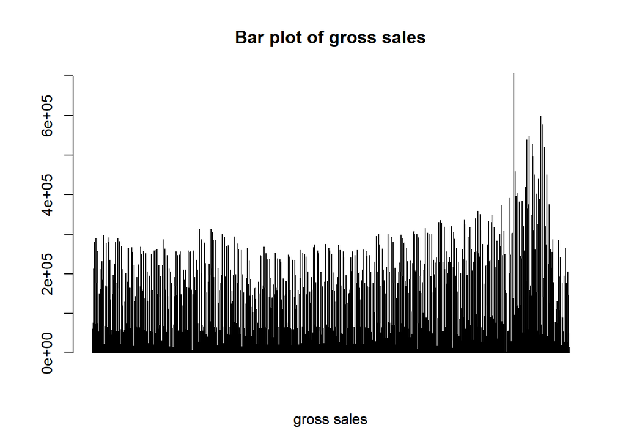

```r
    bar.plot.gross.sales <- barplot(prob.assignment.dataset$gross_sales,main = "Bar plot of gross sales", xlab = "gross sales")
```

```r
    head(bar.plot.gross.sales)
```

```
##      [,1]
## [1,]  0.7
## [2,]  1.9
## [3,]  3.1
## [4,]  4.3
## [5,]  5.5
## [6,]  6.7
```

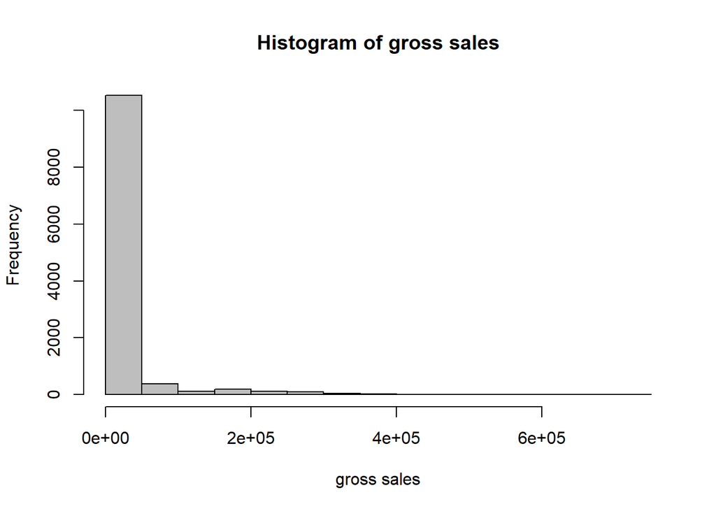

```r
    histogram.gross.sales <- hist(prob.assignment.dataset$gross_sales,main="Histogram of gross sales", xlab="gross sales", col="gray")
```

```r
    head(histogram.gross.sales)
```

```
## $breaks
##  [1]      0  50000 100000 150000 200000 250000 300000 350000 400000 450000
## [11] 500000 550000 600000 650000 700000 750000
##
## $counts
##  [1] 10523   369   116   187   125   104    33    13     4     4     4     2
## [13]     0     0     1
##
## $density
##  [1] 1.832477e-05 6.425773e-07 2.020026e-07 3.256421e-07 2.176752e-07
##  [6] 1.811058e-07 5.746626e-08 2.263822e-08 6.965607e-09 6.965607e-09
## [11] 6.965607e-09 3.482804e-09 0.000000e+00 0.000000e+00 1.741402e-09
##
## $mids
##  [1]  25000  75000 125000 175000 225000 275000 325000 375000 425000 475000
## [11] 525000 575000 625000 675000 725000
##
## $xname
## [1] "prob.assignment.dataset$gross_sales"
##
## $equidist
## [1] TRUE
```

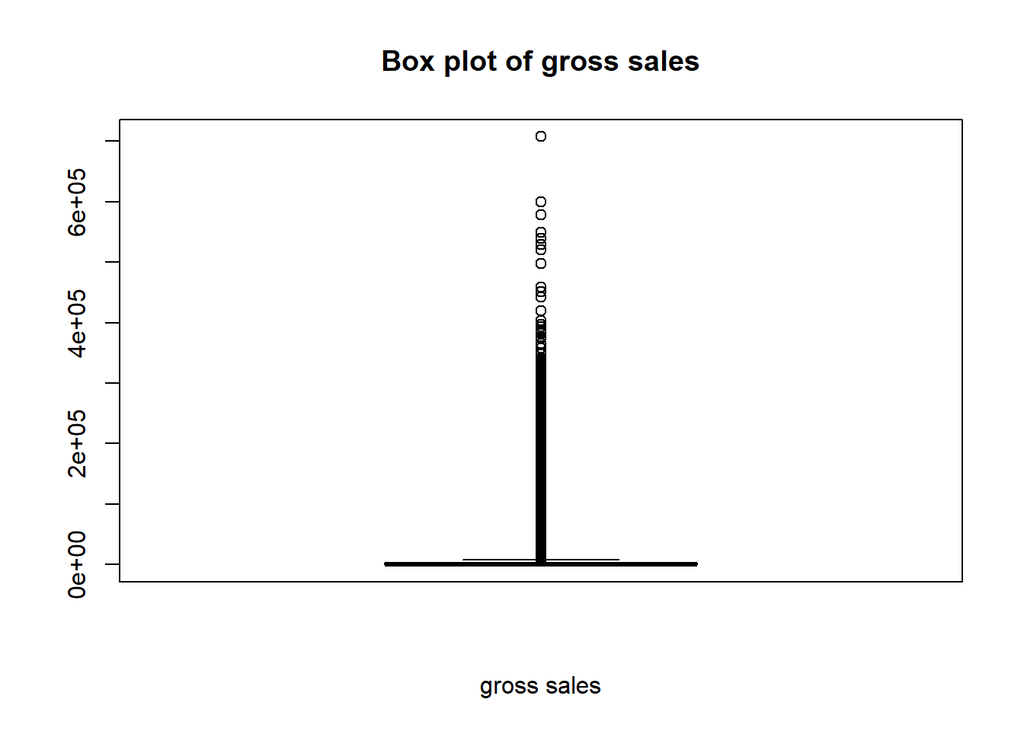

```r
     box.plot.gross.sales <- boxplot(prob.assignment.dataset$gross_sales,main="Box plot of gross sales", xlab="gross sales")
```

```r
     head(box.plot.gross.sales)
```

```
## $stats
##      [,1]
## [1,]    1
## [2,]   79
## [3,]  851
## [4,] 3145
## [5,] 7738
##
## $n
## [1] 11485
##
## $conf
##          [,1]
## [1,] 805.7974
## [2,] 896.2026
```

[output cut: 299 more lines]

#### * Analysis of bounces

```r
    summary.of.bounces <- summary(prob.assignment.dataset$bounces)
    summary.of.bounces
```

```
##    Min. 1st Qu.  Median    Mean 3rd Qu.    Max.
##     0.0     0.0     5.0   743.3    97.0 54512.0
```

```r
    standard.deviation.bounces <- sd(prob.assignment.dataset$bounces,na.rm=TRUE)
    standard.deviation.bounces
```

```
## [1] 3154.698
```

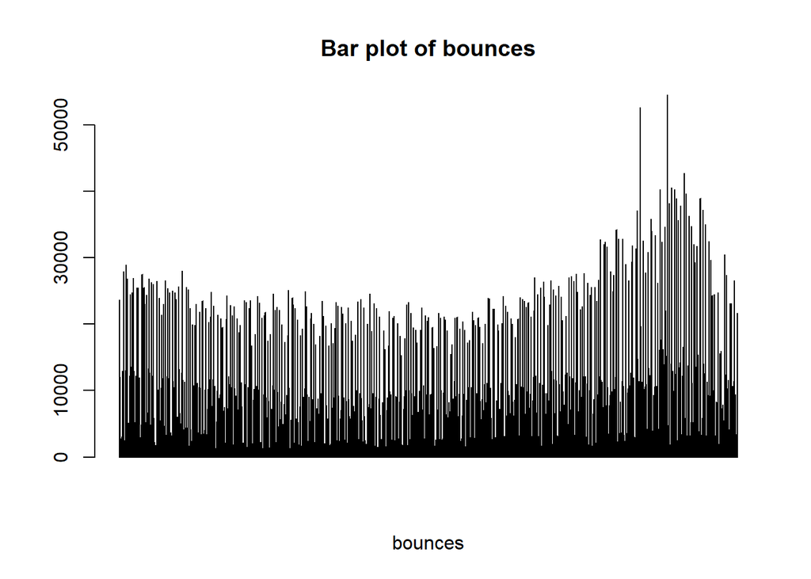

```r
    bar.plot.bounces <- barplot(prob.assignment.dataset$bounces,main = "Bar plot of bounces", xlab = "bounces")
```

```r
    head(bar.plot.bounces)
```

```
##      [,1]
## [1,]  0.7
## [2,]  1.9
## [3,]  3.1
## [4,]  4.3
## [5,]  5.5
## [6,]  6.7
```

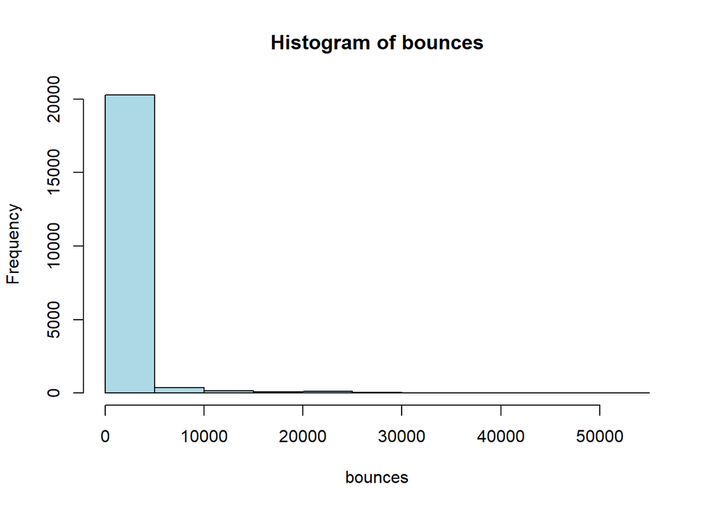

```r
    histogram.bounces <- hist(prob.assignment.dataset$bounces,main="Histogram of bounces", xlab="bounces", col="lightblue")
```

```r
    head(histogram.bounces)
```

```
## $breaks
##  [1]     0  5000 10000 15000 20000 25000 30000 35000 40000 45000 50000 55000
##
## $counts
##  [1] 20256   356   169    65   130    47    22    10     4     0     2
##
## $density
##  [1] 1.923555e-04 3.380656e-06 1.604862e-06 6.172546e-07 1.234509e-06
##  [6] 4.463226e-07 2.089170e-07 9.496225e-08 3.798490e-08 0.000000e+00
## [11] 1.899245e-08
##
## $mids
##  [1]  2500  7500 12500 17500 22500 27500 32500 37500 42500 47500 52500
##
## $xname
## [1] "prob.assignment.dataset$bounces"
##
## $equidist
## [1] TRUE
```

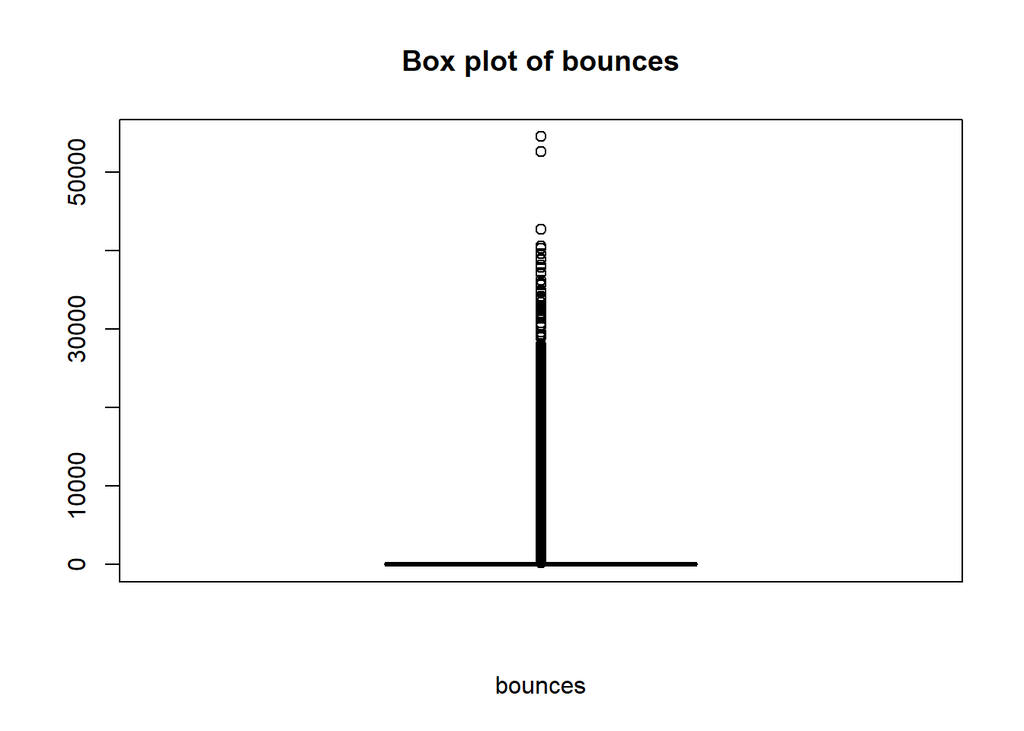

```r
     box.plot.bounces <- boxplot(prob.assignment.dataset$bounces,main="Box plot of bounces", xlab="bounces")
```

```r
     head(box.plot.bounces)
```

```
## $stats
##      [,1]
## [1,]    0
## [2,]    0
## [3,]    5
## [4,]   97
## [5,]  242
##
## $n
## [1] 21061
##
## $conf
##          [,1]
## [1,] 3.943938
## [2,] 6.056062
```

[output cut: 455 more lines]

#### * Analysis of add_to_cart

```r
    summary.of.add_to_cart <- summary(prob.assignment.dataset$add_to_cart)
    summary.of.add_to_cart
```

```
##    Min. 1st Qu.  Median    Mean 3rd Qu.    Max.
##     0.0     0.0     4.0   166.3    43.0  7924.0
```

```r
    standard.deviation.add_to_cart <- sd(prob.assignment.dataset$add_to_cart,na.rm=TRUE)
    standard.deviation.add_to_cart
```

```
## [1] 505.1868
```

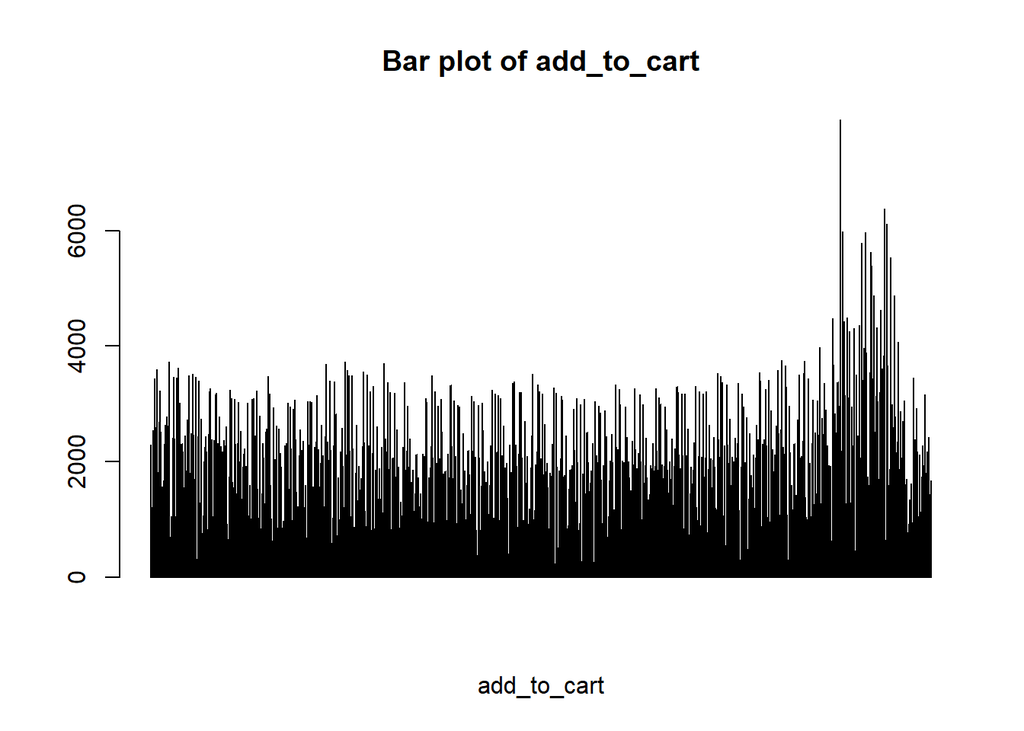

```r
    bar.plot.add_to_cart <- barplot(prob.assignment.dataset$add_to_cart,main = "Bar plot of add_to_cart", xlab = "add_to_cart")
```

```r
    head(bar.plot.add_to_cart)
```

```
##      [,1]
## [1,]  0.7
## [2,]  1.9
## [3,]  3.1
## [4,]  4.3
## [5,]  5.5
## [6,]  6.7
```

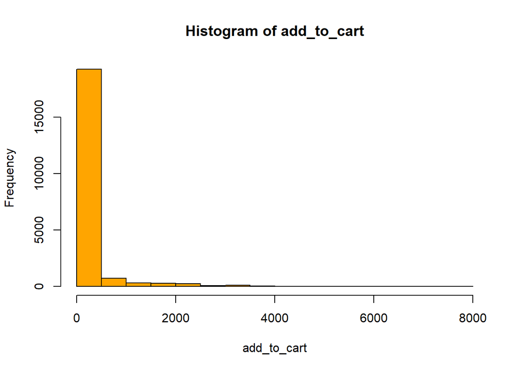

```r
    histogram.add_to_cart <- hist(prob.assignment.dataset$add_to_cart,main="Histogram of add_to_cart", xlab="add_to_cart", col="orange")
```

```r
    head(histogram.add_to_cart)
```

```
## $breaks
##  [1]    0  500 1000 1500 2000 2500 3000 3500 4000 4500 5000 5500 6000 6500 7000
## [16] 7500 8000
##
## $counts
##  [1] 19211   740   326   296   242    82   112    31     9     3     1     5
## [13]     2     0     0     1
##
## $density
##  [1] 1.824320e-03 7.027207e-05 3.095769e-05 2.810883e-05 2.298087e-05
##  [6] 7.786905e-06 1.063577e-05 2.943830e-06 8.546603e-07 2.848868e-07
## [11] 9.496225e-08 4.748113e-07 1.899245e-07 0.000000e+00 0.000000e+00
## [16] 9.496225e-08
##
## $mids
##  [1]  250  750 1250 1750 2250 2750 3250 3750 4250 4750 5250 5750 6250 6750 7250
## [16] 7750
##
## $xname
## [1] "prob.assignment.dataset$add_to_cart"
##
## $equidist
## [1] TRUE
```

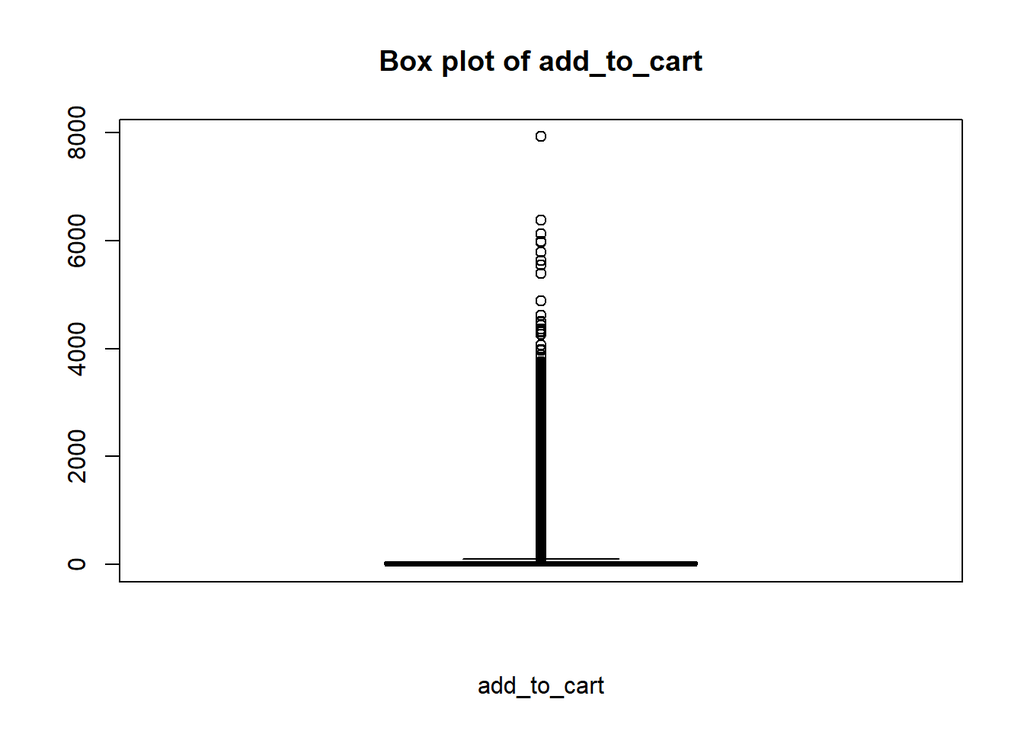

```r
     box.plot.add_to_cart <- boxplot(prob.assignment.dataset$add_to_cart,main="Box plot of add_to_cart", xlab="add_to_cart")
```

```r
     head(box.plot.add_to_cart)
```

```
## $stats
##      [,1]
## [1,]    0
## [2,]    0
## [3,]    4
## [4,]   43
## [5,]  107
##
## $n
## [1] 21061
##
## $conf
##          [,1]
## [1,] 3.531849
## [2,] 4.468151
```

[output cut: 411 more lines]

#### * Analysis of product_page_views

```r
    summary.of.product.page.views <- summary(prob.assignment.dataset$product_page_views)
    summary.of.product.page.views
```

```
##    Min. 1st Qu.  Median    Mean 3rd Qu.    Max.
##       0       3      53    4358     708  187601
```

```r
    standard.deviation.product.page.views <- sd(prob.assignment.dataset$product_page_views,na.rm=TRUE)
    standard.deviation.product.page.views
```

```
## [1] 14327.29
```

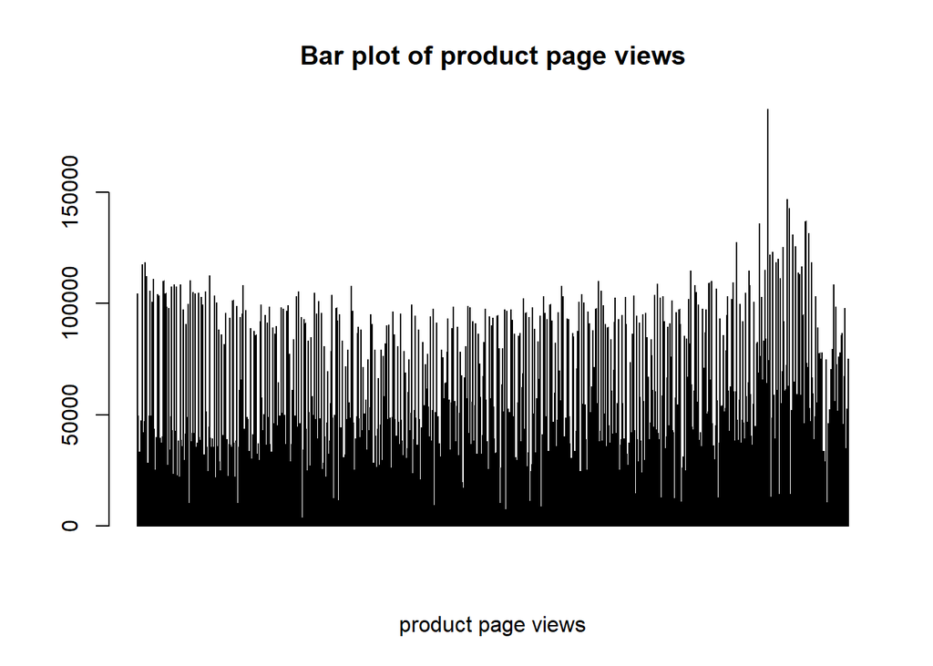

```r
    bar.plot.product.page.views <- barplot(prob.assignment.dataset$product_page_views,main = "Bar plot of product page views", xlab = "product page views")
```

```r
    head(bar.plot.product.page.views)
```

```
##      [,1]
## [1,]  0.7
## [2,]  1.9
## [3,]  3.1
## [4,]  4.3
## [5,]  5.5
## [6,]  6.7
```

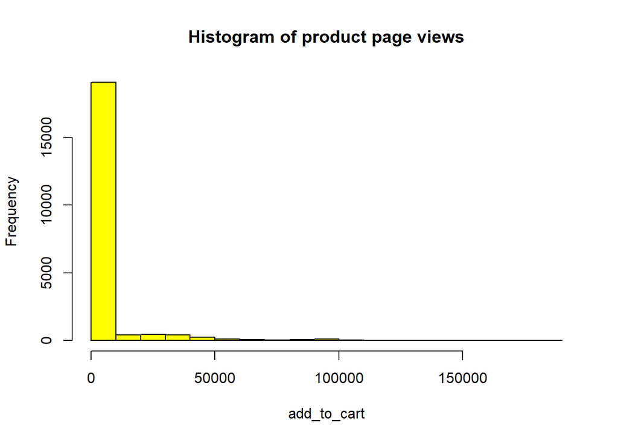

```r
    histogram.product.page.views <- hist(prob.assignment.dataset$product_page_views,main="Histogram of product page views", xlab="add_to_cart", col="yellow")
```

```r
    head(histogram.product.page.views)
```

```
## $breaks
##  [1]      0  10000  20000  30000  40000  50000  60000  70000  80000  90000
## [11] 100000 110000 120000 130000 140000 150000 160000 170000 180000 190000
##
## $counts
##  [1] 19055   429   451   411   243   112    65    50    60    98    56    18
## [13]     6     4     2     0     0     0     1
##
## $density
##  [1] 9.047529e-05 2.036940e-06 2.141399e-06 1.951474e-06 1.153791e-06
##  [6] 5.317886e-07 3.086273e-07 2.374056e-07 2.848868e-07 4.653150e-07
## [11] 2.658943e-07 8.546603e-08 2.848868e-08 1.899245e-08 9.496225e-09
## [16] 0.000000e+00 0.000000e+00 0.000000e+00 4.748113e-09
##
## $mids
##  [1]   5000  15000  25000  35000  45000  55000  65000  75000  85000  95000
## [11] 105000 115000 125000 135000 145000 155000 165000 175000 185000
##
## $xname
## [1] "prob.assignment.dataset$product_page_views"
##
## $equidist
## [1] TRUE
```

#### *Analysis

add to cart are right skewed.

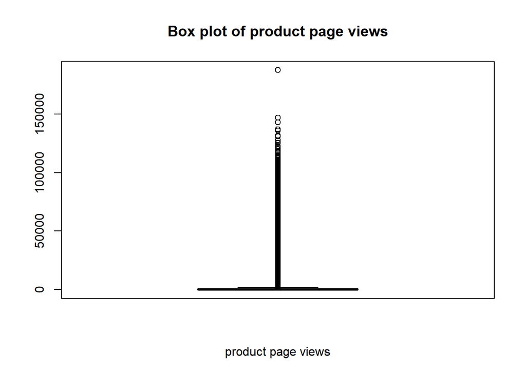

```r
     box.plot.product.page.views <- boxplot(prob.assignment.dataset$product_page_views,main="Box plot of product page views", xlab="product page views")
```

```r
     head(box.plot.product.page.views)
```

```
## $stats
##      [,1]
## [1,]    0
## [2,]    3
## [3,]   53
## [4,]  708
## [5,] 1764
##
## $n
## [1] 21061
##
## $conf
##         [,1]
## [1,] 45.3245
## [2,] 60.6755
```

[output cut: 494 more lines]

#### * Analysis of search_page_views

```r
    summary.of.search.page.views <- summary(prob.assignment.dataset$search_page_views)
    summary.of.search.page.views
```

```
##    Min. 1st Qu.  Median    Mean 3rd Qu.    Max.
##       0       4      82    8584    1229  506629
```

```r
    standard.deviation.search.page.views <- sd(prob.assignment.dataset$search_page_views,na.rm=TRUE)
    standard.deviation.search.page.views
```

```
## [1] 31120.32
```

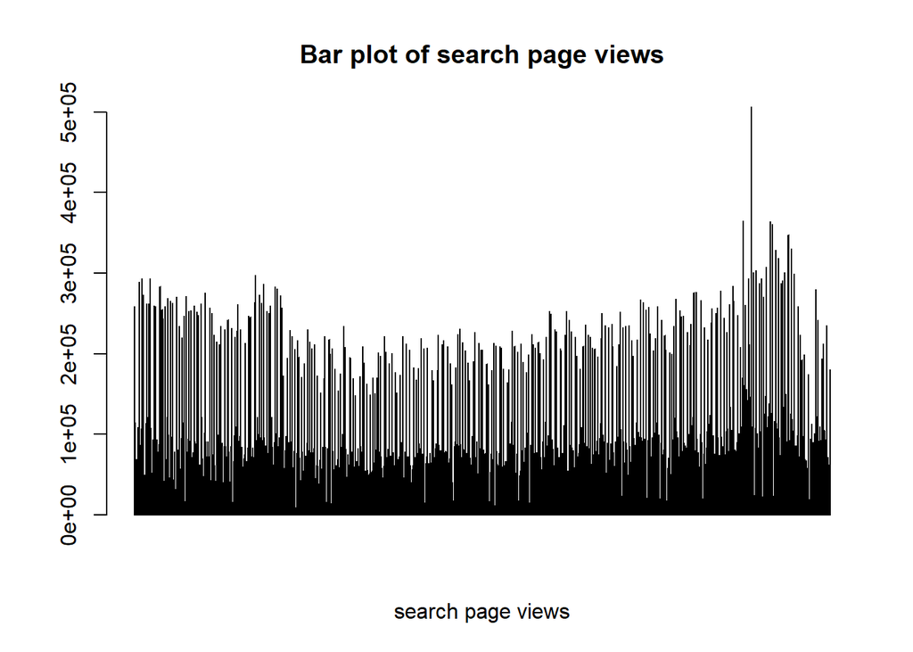

```r
    bar.plot.search.page.views <- barplot(prob.assignment.dataset$search_page_views,main = "Bar plot of search page views", xlab = "search page views")
```

```r
    head(bar.plot.search.page.views)
```

```
##      [,1]
## [1,]  0.7
## [2,]  1.9
## [3,]  3.1
## [4,]  4.3
## [5,]  5.5
## [6,]  6.7
```

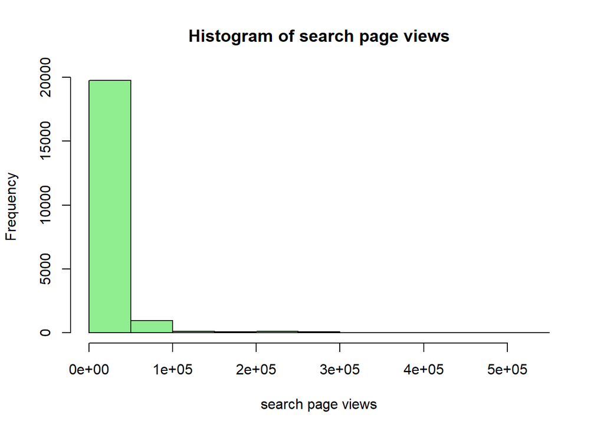

```r
    histogram.search.page.views <- hist(prob.assignment.dataset$search_page_views,main="Histogram of search page views", xlab="search page views", col="lightgreen")
```

```r
    head(histogram.search.page.views)
```

```
## $breaks
##  [1]      0  50000 100000 150000 200000 250000 300000 350000 400000 450000
## [11] 500000 550000
##
## $counts
##  [1] 19734   949   108    66   123    69     8     3     0     0     1
##
## $density
##  [1] 1.873985e-05 9.011918e-07 1.025592e-07 6.267509e-08 1.168036e-07
##  [6] 6.552395e-08 7.596980e-09 2.848868e-09 0.000000e+00 0.000000e+00
## [11] 9.496225e-10
##
## $mids
##  [1]  25000  75000 125000 175000 225000 275000 325000 375000 425000 475000
## [11] 525000
##
## $xname
## [1] "prob.assignment.dataset$search_page_views"
##
## $equidist
## [1] TRUE
```

#### *Analysis

Page views are right skewed.

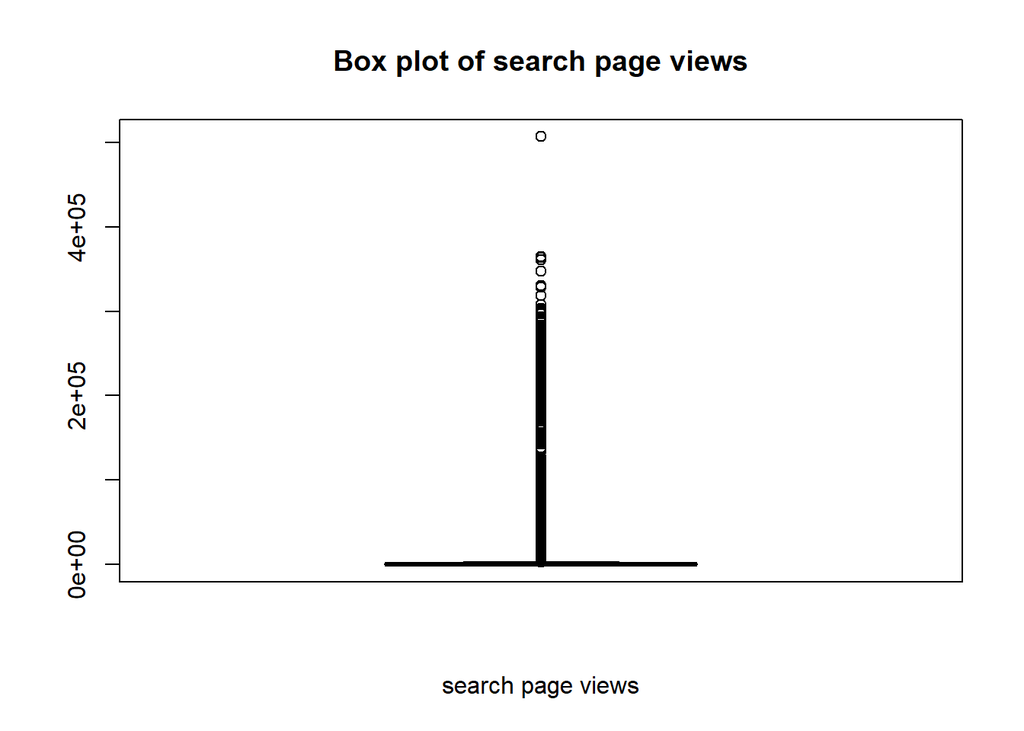

```r
     box.plot.search.page.views <- boxplot(prob.assignment.dataset$search_page_views,main="Box plot of search page views", xlab="search page views")
```

```r
     head(box.plot.search.page.views)
```

```
## $stats
##      [,1]
## [1,]    0
## [2,]    4
## [3,]   82
## [4,] 1229
## [5,] 3064
##
## $n
## [1] 21061
##
## $conf
##          [,1]
## [1,] 68.66314
## [2,] 95.33686
```

[output cut: 471 more lines]

### *Answer for Question 12)

#### * The relationship between platform and site

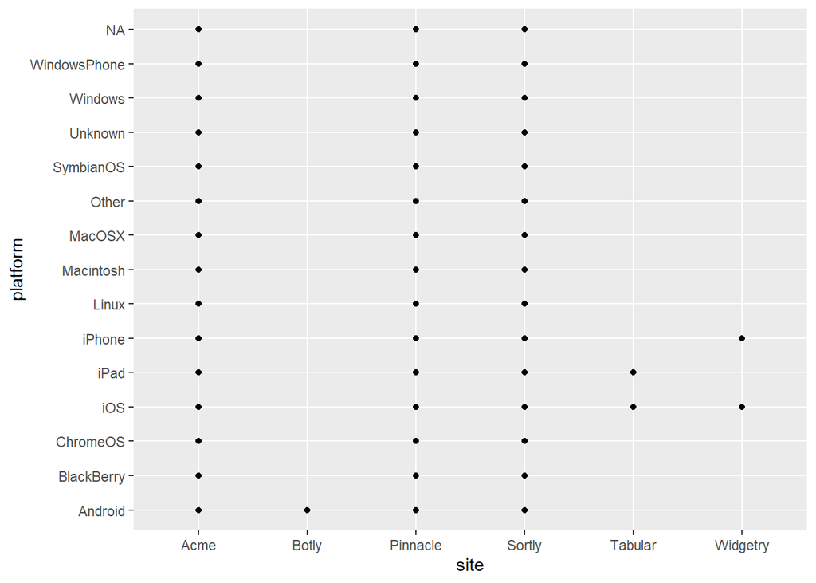

```r
     library('ggplot2')
     qplot(x=site,y=platform,data=prob.assignment.dataset)
```

[figure not shown]

```r
     library('ggplot2')
     ggplot(aes(x=site,y=platform),data=prob.assignment.dataset)+geom_bar(stat="identity")
```

#### * The relationship between Site and orders

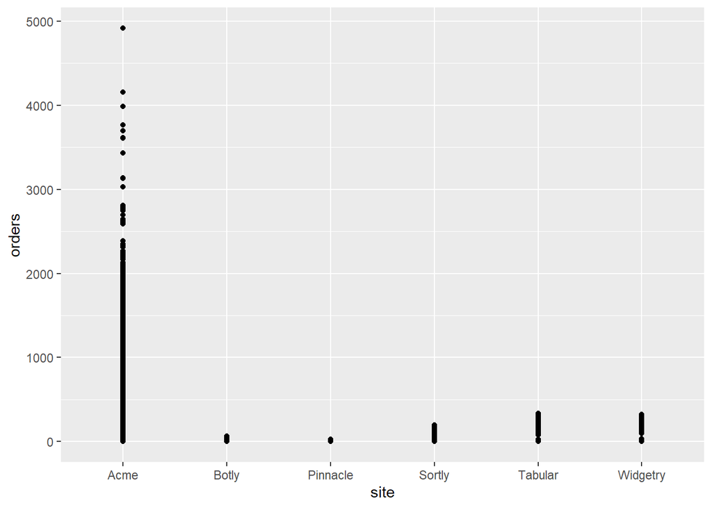

```r
     qplot(x=site,y=orders,data=prob.assignment.dataset)
```

#### *Analysis

Highest orders recevied from the site Acme.

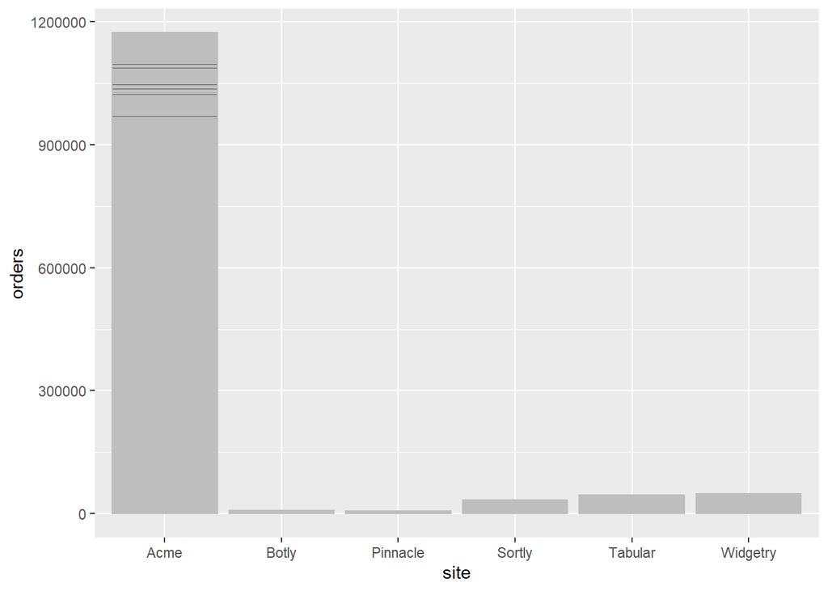

```r
     ggplot(aes(x=site,y=orders),data=prob.assignment.dataset)+geom_bar(stat="identity",color="gray")
```

#### *Analysis

Highest orders recevied from the site Acme.

#### * The relationship between platform and orders

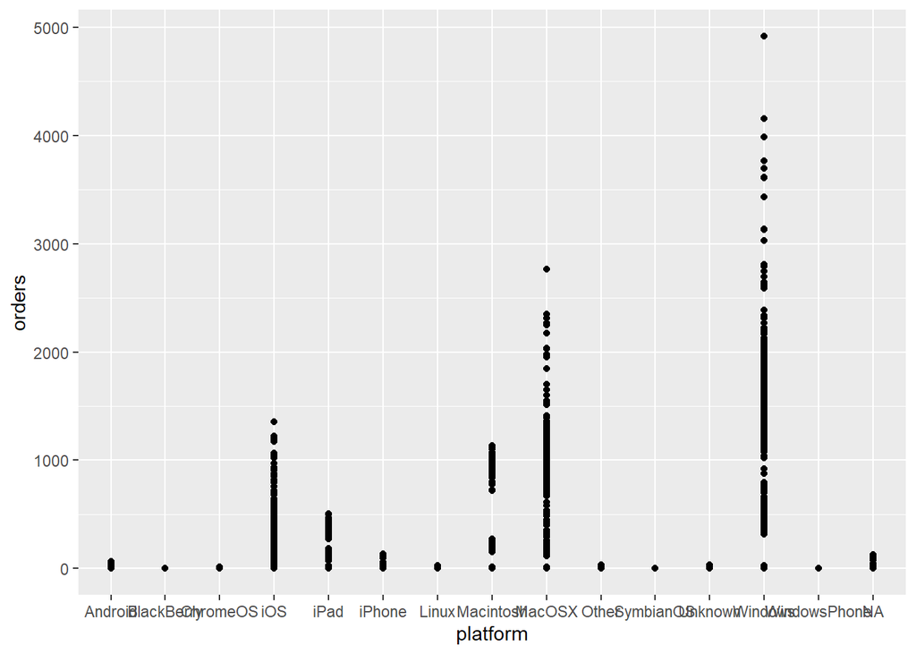

```r
     qplot(x=platform,y=orders,data=prob.assignment.dataset)
```

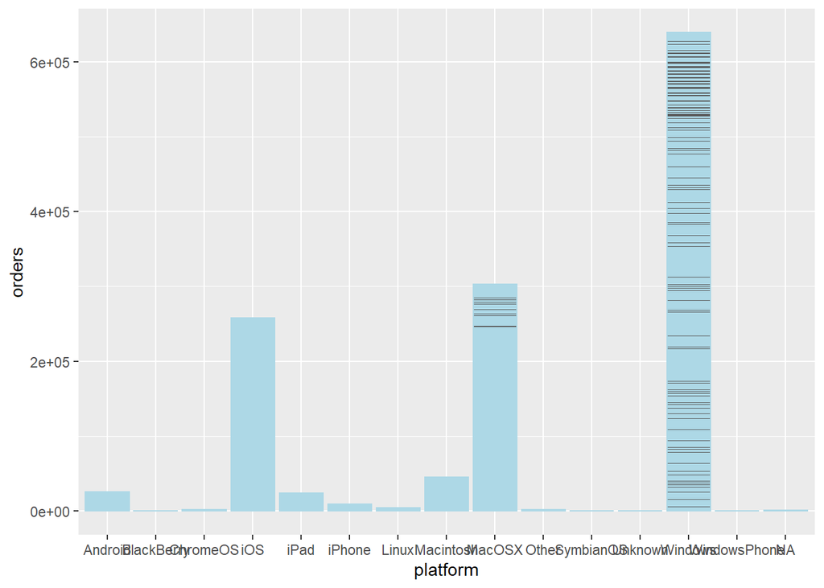

```r
     ggplot(aes(x=platform,y=orders),data=prob.assignment.dataset)+geom_bar(stat="identity",color="lightblue")
```

#### * The relationship between add_to_cart and orders

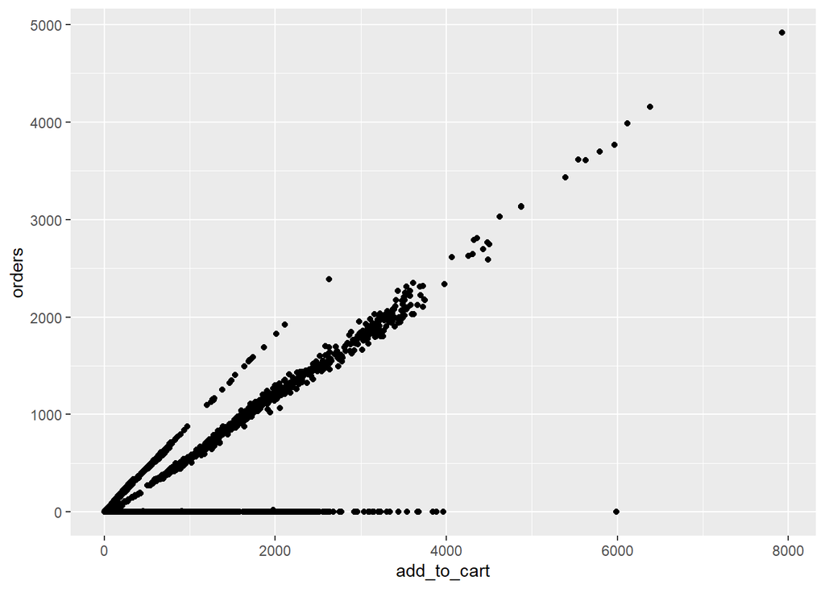

```r
     ggplot(aes(x=add_to_cart,y=orders),data=prob.assignment.dataset)+geom_point(alpha=1)
```